# ЗАДАНИЕ 1. Для финального отчета

**ВАРИАНТ 6 - Даренский Павел, 932201**

1. Постройте stairs-график (ступенчатый) для функции y(x). При построении графиков вид функций и параметры выбрать согласно варианту. Толщину линии, размер и цвет маркера, а также контура маркера подобрать самостоятельно.

```python
import matplotlib.pyplot as plt
from matplotlib.font_manager import FontProperties # Модуль для поиска, управления и использования шрифтов.
import numpy as np
from matplotlib.ticker import AutoMinorLocator
```

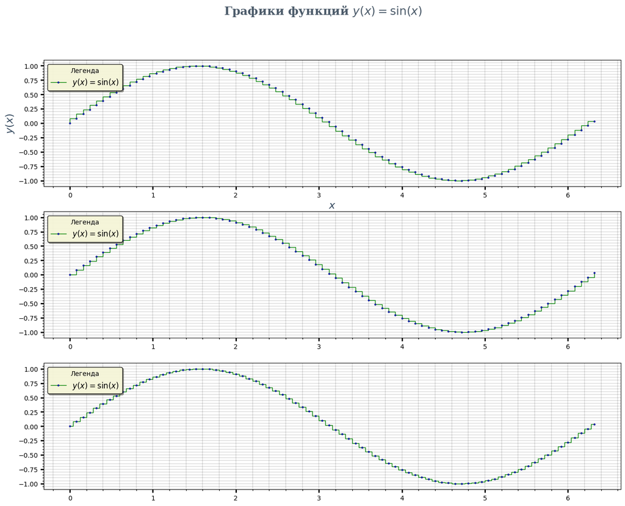

```python
x = np.arange(0, 2*np.pi + 0.08, 0.08)
y = np.sin(x)
where_set = ['pre', 'post', 'mid']  # значения ставятся слева, справа или посередине интервала

# Создание графиков
fig, axs = plt.subplots(3, 1, figsize=(16, 12))

font = FontProperties(family='serif',
                      style='normal',
                      weight='bold',
                      size=18)

# Заголовок
fig.suptitle(r'Графики функций $y(x) = \sin(x)$',
          fontproperties=font,
          alpha=0.85,
          color='#2c3e50',
          linespacing=1.4)

# Построение графиков
for i, ax in enumerate(axs):
    ax.step(x, y, 'g-', marker = '.', markersize=4, linewidth=1,
            markeredgecolor=(0, 0, 139/255), markeredgewidth=1,
            markerfacecolor='dodgerblue', where=where_set[i],
            label=r'$y(x) = \sin(x)$')  # where - определяет место, где будет установлен шаг
    ax.grid()

    # Легенда для каждого графика
    ax.legend(loc='upper left',
              fontsize=12,
              shadow=True,
              framealpha=0.9,
              facecolor='lightyellow',
              edgecolor='black',
              title='Легенда')

# Оси и метки
axs[0].set_xlabel(r'$x$', fontsize=16, fontweight='medium', color='#34495e')
axs[0].set_ylabel(r'$y(x)$', fontsize=16, fontweight='medium', color='#34495e')

# Настройки осей
for ax in axs:
    ax.grid(True)
    ax.xaxis.set_minor_locator(AutoMinorLocator())
    ax.yaxis.set_minor_locator(AutoMinorLocator())
    ax.tick_params(which='major', length=5, width=2)
    ax.tick_params(which='minor', length=2, width=1)
    ax.grid(which='major', linewidth=0.15, color='black')
    ax.grid(which='minor', linestyle='-', color='black', linewidth=0.15)

# Показать график
plt.show()
```

2. Постройте stem-график для функции y(x), 𝑥 ∈ [0,2𝜋], ∆𝑥 = 0,2. При построении графиков вид функций и параметры выбрать согласно варианту. Толщину линии, размер и цвет маркера, а также контура маркера подобрать самостоятельно.

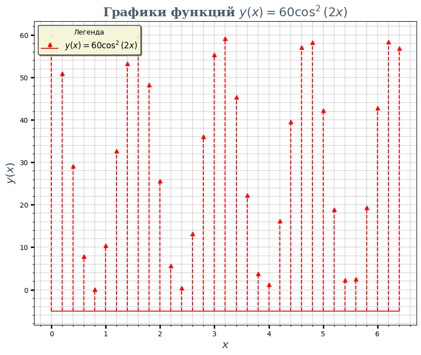

```python
x = np.arange(0, 2*np.pi + 0.2, 0.2)
y = 60 * np.cos(2*x) * np.cos(2*x)

# Настройка графика
plt.figure(figsize=(10, 8))

font = FontProperties(family='serif',
                      style='normal',
                      weight='bold',
                      size=18)

# Заголовок
plt.title(r'Графики функций $y(x) = 60\cos^2(2x)$',
          fontproperties=font,
          alpha=0.85,
          color='#2c3e50',
          linespacing=1.4)

plt.stem(x, y,
         linefmt='r--',    # тип и цвет вертикальной линии
         markerfmt='^',    # тип маркера
         bottom=-5,
         label=r'$y(x) = 60\cos^2(2x)$');        # y-координата базовой линии (по умолчанию 0)

# Оси и метки
plt.xlabel(r'$x$', fontsize=16, fontweight='medium', color='#34495e')
plt.ylabel(r'$y(x)$', fontsize=16, fontweight='medium', color='#34495e')

# Легенда
plt.legend(loc='upper left',
           fontsize=12,
           shadow=True,
           framealpha=0.9,
           facecolor='lightyellow',
           edgecolor='black',
           title='Легенда')

# Настройки осей
ax = plt.gca()
ax.grid(True)
ax.xaxis.set_minor_locator(AutoMinorLocator())
ax.yaxis.set_minor_locator(AutoMinorLocator())
ax.tick_params(which='major', length=5, width=2)
ax.tick_params(which='minor', length=2, width=1)
ax.grid(which='major', linewidth=0.15, color='black')
ax.grid(which='minor', linestyle='-', color='black', linewidth=0.15)

# Показать график
plt.show()
```

3. Вам необходимо установить зависимость между двумя переменными (согласно варианту), а также исследовать некоторую динамику по годам.
- Постройте диаграмму рассеяния и сделайте по результатам построения вывод о наличии и характере связи.
- Постройте столбчатую диаграмму, согласно варианту.
- Постройте круговую диаграмму согласно варианту.
- Все параметры диаграмм подобрать самостоятельно.

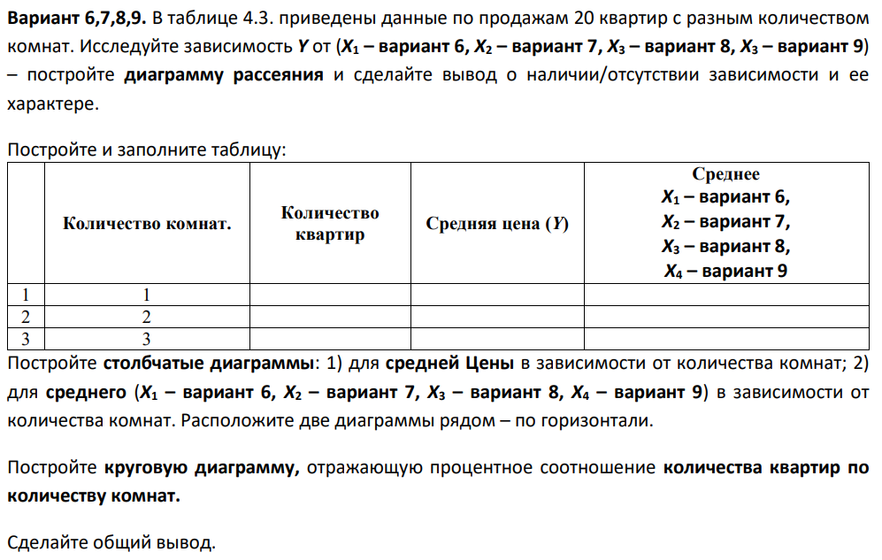

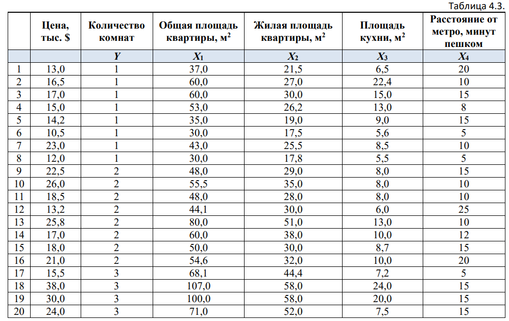

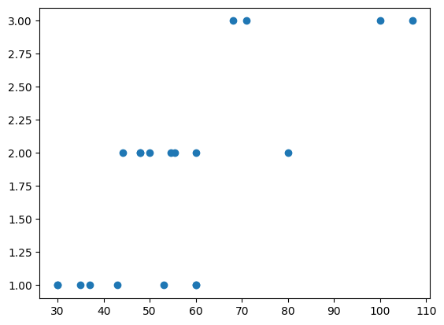

```python
x = np.array([37.0, 60.0, 60.0, 53.0, 35.0, 30.0, 43.0, 30.0, 48.0, 55.5, 48.0, 44.1, 80.0, 60.0, 50.0, 54.6, 68.1, 107.0, 100.0, 71.0]) # X1
y = np.array([1, 1, 1, 1, 1, 1, 1, 1, 2, 2, 2, 2, 2, 2, 2, 2, 3, 3, 3, 3]) # num of rooms
plt.scatter(x, y);
```

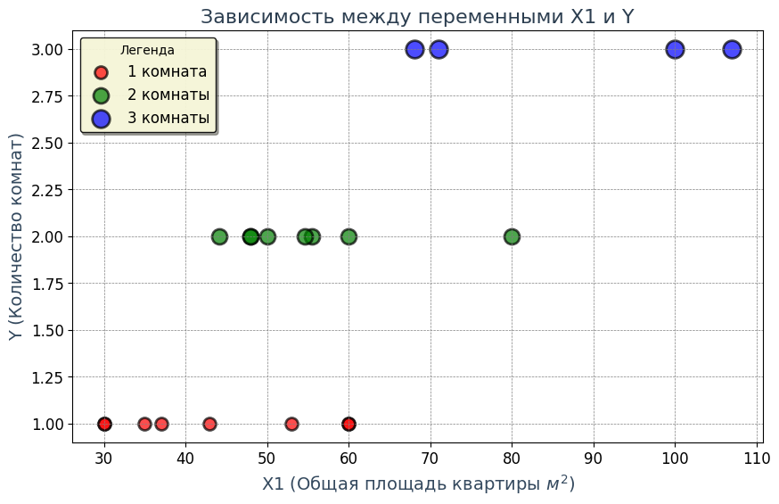

```python
x = np.array([37.0, 60.0, 60.0, 53.0, 35.0, 30.0, 43.0, 30.0, 48.0, 55.5, 48.0, 44.1, 80.0, 60.0, 50.0, 54.6, 68.1, 107.0, 100.0, 71.0])  # X1
y = np.array([1, 1, 1, 1, 1, 1, 1, 1, 2, 2, 2, 2, 2, 2, 2, 2, 3, 3, 3, 3])  # Y

# Цвета для каждой категории
color_map = {1: 'r', 2: 'g', 3: 'b'}

colors = [color_map[val] for val in y]

# Настроим размеры маркеров
sizes = np.array([100, 150, 200])

plt.figure(figsize=(10, 6))

# Отдельно рисуем три категории для легенды
scatter1 = plt.scatter(x[y == 1], y[y == 1], s=sizes[0], alpha=0.7, c='r', label='1 комната', linewidths=2, edgecolors='black')
scatter2 = plt.scatter(x[y == 2], y[y == 2], s=sizes[1], alpha=0.7, c='g', label='2 комнаты', linewidths=2, edgecolors='black')
scatter3 = plt.scatter(x[y == 3], y[y == 3], s=sizes[2], alpha=0.7, c='b', label='3 комнаты', linewidths=2, edgecolors='black')

plt.title('Зависимость между переменными X1 и Y', fontsize=16, fontweight='normal', color='#2c3e50')
plt.xlabel(r'X1 (Общая площадь квартиры $м^2$)', fontsize=14, fontweight='medium', color='#34495e')
plt.ylabel('Y (Количество комнат)', fontsize=14, fontweight='medium', color='#34495e')

plt.legend(loc='upper left', fontsize=12, shadow=True, title='Легенда', framealpha=0.9, facecolor='lightyellow', edgecolor='black')

plt.grid(True, which='both', axis='both', linestyle='--', linewidth=0.5, color='gray')
plt.xticks(fontsize=12)
plt.yticks(fontsize=12)

plt.show()
```

Вывод: оценка зависимости между количественной переменной и категориальной следующая: зависимость наблюдается линейная (что логично при увеличении комнат и далее на столбчатой диаграмме будет это заметнее видно), оценивать зависимость между количественной переменной и категориальной.

```
   Количество комнат  Количество_квартир  Средняя_цена  Среднее_Площадь
0                  1                   8        15.150           43.500
1                  2                   8        20.250           55.025
2                  3                   4        26.875           86.525
```

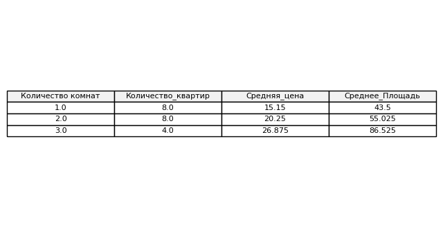

```python
import pandas as pd

prices = np.array([13.0, 16.5, 17.0, 15.0, 14.2, 10.5, 23.0, 12.0, 22.5, 26.0, 18.5, 13.2, 25.8, 17.0, 18.0, 21.0, 15.5, 38.0, 30.0, 24.0]) # prices ($)

# Создаем DataFrame
data = pd.DataFrame({
    'Площадь': x,
    'Количество комнат': y,
    'Цена': prices
})

# Создадим сводную таблицу
table = data.groupby('Количество комнат').agg(
    Количество_квартир=('Площадь', 'size'),
    Средняя_цена=('Цена', 'mean'),
    Среднее_Площадь=('Площадь', 'mean')
).reset_index()

# Выводим таблицу
print(table)

# Отображаем таблицу на графике
fig, ax = plt.subplots(figsize=(8, 4))
ax.axis('tight')
ax.axis('off')
ax.table(cellText=table.values, colLabels=table.columns, loc='center', cellLoc='center', colColours=["#f2f2f2"]*table.shape[1])

plt.show()
```

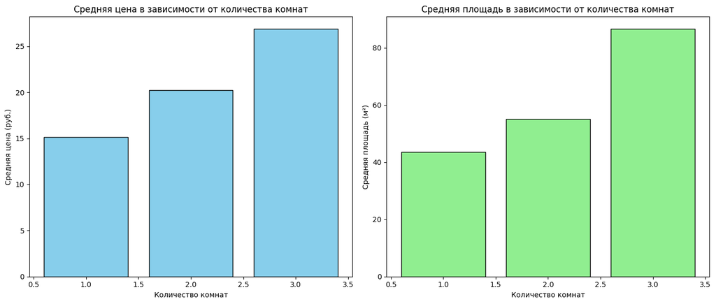

```python
fig, (ax1, ax2) = plt.subplots(1, 2, figsize=(14, 6))

# Средняя цена по количеству комнат
ax1.bar(table['Количество комнат'], table['Средняя_цена'], color='skyblue', edgecolor='black')
ax1.set_title('Средняя цена в зависимости от количества комнат')
ax1.set_xlabel('Количество комнат')
ax1.set_ylabel('Средняя цена (руб.)')

# Средняя площадь по количеству комнат
ax2.bar(table['Количество комнат'], table['Среднее_Площадь'], color='lightgreen', edgecolor='black')
ax2.set_title('Средняя площадь в зависимости от количества комнат')
ax2.set_xlabel('Количество комнат')
ax2.set_ylabel('Средняя площадь (м²)')

plt.tight_layout()
plt.show()
```

Вывод: как и говорилось ранее, здесь визуально заметнее как при росте количества комнат цена и площадь средние тоже дают рост.

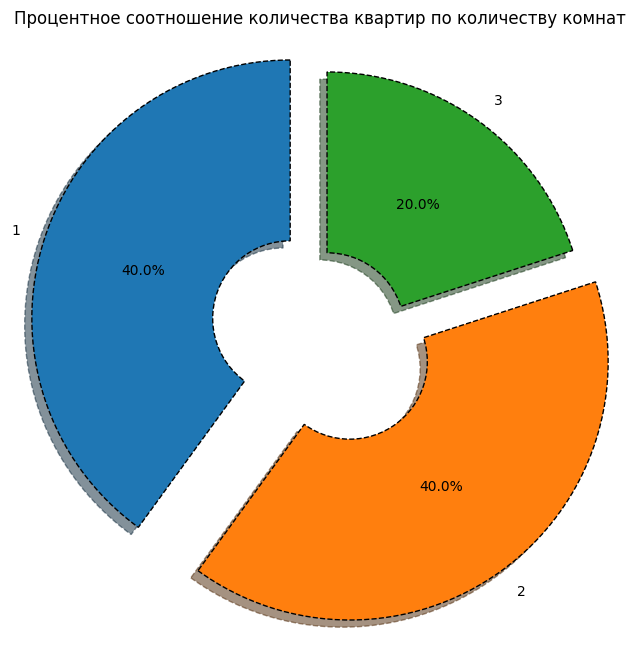

```python
labels = table['Количество комнат'].astype(str)  # метки (1, 2, 3 комнаты)
sizes = table['Количество_квартир']  # количество квартир для каждой категории
explode = (0.15, 0.15, 0)  # выносим сектор с наибольшим количеством квартир (для выделения)

fig, ax = plt.subplots(figsize=(8, 8))
ax.pie(sizes, labels=labels, autopct='%1.1f%%', startangle=90, shadow=True, explode=explode, wedgeprops=dict(width=0.7, linestyle='--', edgecolor='black'))

ax.axis('equal')

plt.title('Процентное соотношение количества квартир по количеству комнат')
plt.show()
```

Вывод: на круговой диаграмме видно соотношение квартир с разным количеством комнат из нашей выборки. Квартир с 1 и 2 комнатами по 40%, квартир с 3 комнатами 20%.